# Actual Branch Length Analysis

## Goal

The primary goal of this analysis is to determine if the literal branch length estimates themselves differ across protein models.  
First, let’s read in the datasets and create smaller versions of them that are easier to work with, just like last time.

## The enzyme, mammal, and enzyme data all together

```r
print(full_data)
```

```
## # A tibble: 11,701,650 × 6
##    id                 model ASRV   node branch_length dataset
##    <chr>              <chr> <lgl> <dbl>         <dbl> <chr>
##  1 ENSG00000000003_AA FLU   FALSE     1       0.00472 mammals
##  2 ENSG00000000003_AA FLU   FALSE     2       0.0250  mammals
##  3 ENSG00000000003_AA FLU   FALSE     3       0.00822 mammals
##  4 ENSG00000000003_AA FLU   FALSE     4       0.0294  mammals
##  5 ENSG00000000003_AA FLU   FALSE     5       0.0122  mammals
##  6 ENSG00000000003_AA FLU   FALSE     6       0.0504  mammals
##  7 ENSG00000000003_AA FLU   FALSE     7       0.0203  mammals
##  8 ENSG00000000003_AA FLU   FALSE     8       0.00801 mammals
##  9 ENSG00000000003_AA FLU   FALSE     9       0.0168  mammals
## 10 ENSG00000000003_AA FLU   FALSE    10       0.00440 mammals
## # … with 11,701,640 more rows
```

## The data pivoted wide to show all models’ branch lengths and pivoted again to compare Poisson branch lengths with all others

```r
full_data %>%
  unite(combined_model, model, ASRV) %>%
  group_by(id, dataset) %>%
  pivot_wider(names_from = combined_model,
              values_from = branch_length) %>%
  ungroup() -> input_data

input_data%>%
pivot_longer( -c(id, node, dataset, Poisson_FALSE), names_to = "model_type", values_to = "branchlength")->input_poisson_f
```

## Let’s see how one looks to get a better sense of the data we’re modeling

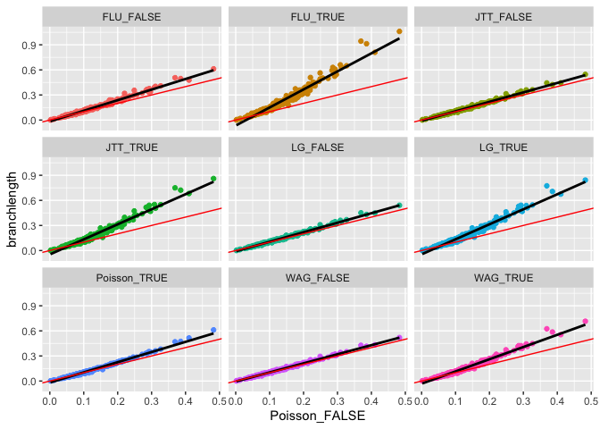

```
## # A tibble: 1,170,165 × 13
##    id        node dataset FLU_FALSE FLU_TRUE JTT_FALSE JTT_TRUE LG_FALSE LG_TRUE
##    <chr>    <dbl> <chr>       <dbl>    <dbl>     <dbl>    <dbl>    <dbl>   <dbl>
##  1 ENSG000…     1 mammals   0.00472  0.00554   0.00467  0.00496  0.00469 0.00530
##  2 ENSG000…     2 mammals   0.0250   0.0310    0.0248   0.0276   0.0249  0.0296
##  3 ENSG000…     3 mammals   0.00822  0.00994   0.00824  0.00911  0.00826 0.00979
##  4 ENSG000…     4 mammals   0.0294   0.0363    0.0290   0.0321   0.0290  0.0344
##  5 ENSG000…     5 mammals   0.0122   0.0150    0.0123   0.0136   0.0122  0.0142
##  6 ENSG000…     6 mammals   0.0504   0.0633    0.0504   0.0574   0.0506  0.0619
##  7 ENSG000…     7 mammals   0.0203   0.0249    0.0203   0.0225   0.0204  0.0241
##  8 ENSG000…     8 mammals   0.00801  0.00955   0.00809  0.00881  0.00806 0.00927
##  9 ENSG000…     9 mammals   0.0168   0.0206    0.0166   0.0184   0.0168  0.0201
## 10 ENSG000…    10 mammals   0.00440  0.00512   0.00447  0.00475  0.00439 0.00501
## # … with 1,170,155 more rows, and 4 more variables: Poisson_FALSE <dbl>,
## #   Poisson_TRUE <dbl>, WAG_FALSE <dbl>, WAG_TRUE <dbl>
```

```
## # A tibble: 10,531,485 × 6
##    id                  node dataset Poisson_FALSE model_type   branchlength
##    <chr>              <dbl> <chr>           <dbl> <chr>               <dbl>
##  1 ENSG00000000003_AA     1 mammals       0.00462 FLU_FALSE         0.00472
##  2 ENSG00000000003_AA     1 mammals       0.00462 FLU_TRUE          0.00554
##  3 ENSG00000000003_AA     1 mammals       0.00462 JTT_FALSE         0.00467
##  4 ENSG00000000003_AA     1 mammals       0.00462 JTT_TRUE          0.00496
##  5 ENSG00000000003_AA     1 mammals       0.00462 LG_FALSE          0.00469
##  6 ENSG00000000003_AA     1 mammals       0.00462 LG_TRUE           0.00530
##  7 ENSG00000000003_AA     1 mammals       0.00462 Poisson_TRUE      0.00485
##  8 ENSG00000000003_AA     1 mammals       0.00462 WAG_FALSE         0.00466
##  9 ENSG00000000003_AA     1 mammals       0.00462 WAG_TRUE          0.00493
## 10 ENSG00000000003_AA     2 mammals       0.0248  FLU_FALSE         0.0250
## # … with 10,531,475 more rows
```

## Perform a glm of OFFSETTED branchlength~Poisson_FALSE, with the help of `tidyr::nest()` and `{broom}`.

> The slope is *forced to be 1*. The intercept therefore tells us the *bias of the esimator* compared to truth. We “define truth” as Poisson_FALSE Intercept means: What is the difference between other model’s bl - Poisson_FALSE bl

```r
input_poisson_f%>%
  select(-node) %>%
  group_by(id, dataset, model_type)%>%
  tidyr::nest()%>%
  mutate(lm_fit=map(data, ~glm(branchlength ~ offset(Poisson_FALSE), data=.)))->nested


nested%>%
  select(-data)%>%
  mutate(tidied=map(lm_fit, broom::tidy))%>%
  unnest(cols = c(tidied))->unnested

unnested%>%
  filter(term == "(Intercept)")%>%
  select(id, dataset, model_type, estimate)%>%
  rename(intercept=estimate)->Intercepts_df

readr::write_csv(Intercepts_df, "biasintercepts_poisson_false.csv")
```

## Analysis

-There is less deiscepency bewteen ASRV- plots, but more when you compare ASRV- to ASRV+